# Risk Factor Analysis

## Outcome Variable

**Outcome Variable:** whz

## Predictor Variables

**Intervention Variable:** mbmi

**Adjustment Set:**

- arm
- W_mage
- W_fage
- meducyrs
- feducyrs
- single
- brthmon
- delta_W_mage
- delta_W_fage
- delta_meducyrs
- delta_feducyrs
- delta_single
- delta_brthmon

## Stratifying Variables

The analysis was stratified on these variable(s):

- agecat
- studyid
- country

## Data Summary

| agecat | studyid | country | mbmi | n_cell | n |
| --- | --- | --- | --- | --- | --- |
| Birth | ki0047075b-MAL-ED | BANGLADESH | Normal weight | 205 | 233 |
| Birth | ki0047075b-MAL-ED | BANGLADESH | Underweight | 28 | 233 |
| Birth | ki0047075b-MAL-ED | BRAZIL | Normal weight | 167 | 176 |
| Birth | ki0047075b-MAL-ED | BRAZIL | Underweight | 9 | 176 |
| Birth | ki0047075b-MAL-ED | INDIA | Normal weight | 157 | 195 |
| Birth | ki0047075b-MAL-ED | INDIA | Underweight | 38 | 195 |
| Birth | ki0047075b-MAL-ED | NEPAL | Normal weight | 167 | 167 |
| Birth | ki0047075b-MAL-ED | NEPAL | Underweight | 0 | 167 |
| Birth | ki0047075b-MAL-ED | PERU | Normal weight | 264 | 269 |
| Birth | ki0047075b-MAL-ED | PERU | Underweight | 5 | 269 |
| Birth | ki0047075b-MAL-ED | SOUTH AFRICA | Normal weight | 221 | 226 |
| Birth | ki0047075b-MAL-ED | SOUTH AFRICA | Underweight | 5 | 226 |
| Birth | ki0047075b-MAL-ED | TANZANIA, UNITED REPUBLIC OF | Normal weight | 109 | 116 |
| Birth | ki0047075b-MAL-ED | TANZANIA, UNITED REPUBLIC OF | Underweight | 7 | 116 |
| Birth | ki1000304b-SAS-CompFeed | INDIA | Normal weight | 77 | 110 |
| Birth | ki1000304b-SAS-CompFeed | INDIA | Underweight | 33 | 110 |
| Birth | ki1017093-NIH-Birth | BANGLADESH | Normal weight | 23 | 28 |
| Birth | ki1017093-NIH-Birth | BANGLADESH | Underweight | 5 | 28 |
| Birth | ki1017093c-NIH-Crypto | BANGLADESH | Normal weight | 17 | 23 |
| Birth | ki1017093c-NIH-Crypto | BANGLADESH | Underweight | 6 | 23 |
| Birth | ki1119695-PROBIT | BELARUS | Normal weight | 13143 | 13664 |
| Birth | ki1119695-PROBIT | BELARUS | Underweight | 521 | 13664 |
| Birth | ki1126311-ZVITAMBO | ZIMBABWE | Normal weight | 8573 | 9029 |
| Birth | ki1126311-ZVITAMBO | ZIMBABWE | Underweight | 456 | 9029 |
| 6 months | ki0047075b-MAL-ED | BANGLADESH | Normal weight | 209 | 241 |
| 6 months | ki0047075b-MAL-ED | BANGLADESH | Underweight | 32 | 241 |
| 6 months | ki0047075b-MAL-ED | BRAZIL | Normal weight | 199 | 208 |
| 6 months | ki0047075b-MAL-ED | BRAZIL | Underweight | 9 | 208 |
| 6 months | ki0047075b-MAL-ED | INDIA | Normal weight | 186 | 235 |
| 6 months | ki0047075b-MAL-ED | INDIA | Underweight | 49 | 235 |

[output cut: 52 more lines]

The following strata were considered:

- agecat: 24 months, studyid: ki0047075b-MAL-ED, country: BANGLADESH
- agecat: 24 months, studyid: ki0047075b-MAL-ED, country: BRAZIL
- agecat: 24 months, studyid: ki0047075b-MAL-ED, country: INDIA
- agecat: 24 months, studyid: ki0047075b-MAL-ED, country: NEPAL
- agecat: 24 months, studyid: ki0047075b-MAL-ED, country: PERU
- agecat: 24 months, studyid: ki0047075b-MAL-ED, country: SOUTH AFRICA
- agecat: 24 months, studyid: ki0047075b-MAL-ED, country: TANZANIA, UNITED REPUBLIC OF
- agecat: 24 months, studyid: ki1017093-NIH-Birth, country: BANGLADESH
- agecat: 24 months, studyid: ki1017093b-PROVIDE, country: BANGLADESH
- agecat: 24 months, studyid: ki1017093c-NIH-Crypto, country: BANGLADESH
- agecat: 24 months, studyid: ki1066203-TanzaniaChild2, country: TANZANIA, UNITED REPUBLIC OF
- agecat: 24 months, studyid: ki1119695-PROBIT, country: BELARUS
- agecat: 24 months, studyid: ki1126311-ZVITAMBO, country: ZIMBABWE
- agecat: 24 months, studyid: ki1148112-LCNI-5, country: MALAWI
- agecat: 6 months, studyid: ki0047075b-MAL-ED, country: BANGLADESH
- agecat: 6 months, studyid: ki0047075b-MAL-ED, country: BRAZIL
- agecat: 6 months, studyid: ki0047075b-MAL-ED, country: INDIA
- agecat: 6 months, studyid: ki0047075b-MAL-ED, country: NEPAL
- agecat: 6 months, studyid: ki0047075b-MAL-ED, country: PERU
- agecat: 6 months, studyid: ki0047075b-MAL-ED, country: SOUTH AFRICA
- agecat: 6 months, studyid: ki0047075b-MAL-ED, country: TANZANIA, UNITED REPUBLIC OF
- agecat: 6 months, studyid: ki1000304b-SAS-CompFeed, country: INDIA
- agecat: 6 months, studyid: ki1017093-NIH-Birth, country: BANGLADESH
- agecat: 6 months, studyid: ki1017093b-PROVIDE, country: BANGLADESH
- agecat: 6 months, studyid: ki1017093c-NIH-Crypto, country: BANGLADESH
- agecat: 6 months, studyid: ki1066203-TanzaniaChild2, country: TANZANIA, UNITED REPUBLIC OF
- agecat: 6 months, studyid: ki1119695-PROBIT, country: BELARUS
- agecat: 6 months, studyid: ki1126311-ZVITAMBO, country: ZIMBABWE
- agecat: 6 months, studyid: ki1148112-LCNI-5, country: MALAWI
- agecat: Birth, studyid: ki0047075b-MAL-ED, country: BANGLADESH
- agecat: Birth, studyid: ki0047075b-MAL-ED, country: BRAZIL
- agecat: Birth, studyid: ki0047075b-MAL-ED, country: INDIA
- agecat: Birth, studyid: ki0047075b-MAL-ED, country: NEPAL
- agecat: Birth, studyid: ki0047075b-MAL-ED, country: PERU
- agecat: Birth, studyid: ki0047075b-MAL-ED, country: SOUTH AFRICA
- agecat: Birth, studyid: ki0047075b-MAL-ED, country: TANZANIA, UNITED REPUBLIC OF
- agecat: Birth, studyid: ki1000304b-SAS-CompFeed, country: INDIA
- agecat: Birth, studyid: ki1017093-NIH-Birth, country: BANGLADESH
- agecat: Birth, studyid: ki1017093c-NIH-Crypto, country: BANGLADESH
- agecat: Birth, studyid: ki1119695-PROBIT, country: BELARUS
- agecat: Birth, studyid: ki1126311-ZVITAMBO, country: ZIMBABWE

### Dropped Strata

Some strata were dropped due to rare outcomes:

- agecat: Birth, studyid: ki0047075b-MAL-ED, country: NEPAL
- agecat: 6 months, studyid: ki0047075b-MAL-ED, country: NEPAL
- agecat: 24 months, studyid: ki0047075b-MAL-ED, country: NEPAL
- agecat: 24 months, studyid: ki0047075b-MAL-ED, country: PERU
- agecat: 24 months, studyid: ki1066203-TanzaniaChild2, country: TANZANIA, UNITED REPUBLIC OF

## Methods Detail

We’re interested in the causal parameters $E[Y_a]$ for all values of $a \in \mathcal{A}$. These parameters represent the mean outcome if, possibly contrary to fact, we intervened to set all units to have $A=a$. Under the randomization and positivity assumptions, these are identified by the statistical parameters $\psi_a=E_W[E_{Y|A,W}(Y|A=a,W)]$. In addition, we’re interested in the mean of $Y$, $E[Y]$ under no intervention (the observed mean). We will estimate these parameters by using SuperLearner to fit the relevant likelihood factors – $E_{Y|A,W}(Y|A=a,W)$ and $p(A=a|W)$, and then updating our likelihood fit using a joint TMLE.

For unadjusted analyses ($W=\{\}$), initial likelihoods were estimated using Lrnr_glm to estimate the simple $E(Y|A)$ and Lrnr_mean to estimate $p(A)$. For adjusted analyses, a small library containing Lrnr_glmnet, Lrnr_xgboost, and Lrnr_mean was used.

Having estimated these parameters, we will then use the delta method to estimate relative risks and attributable risks relative to a prespecified baseline level of $A$.

# Results Detail

## Results Plots

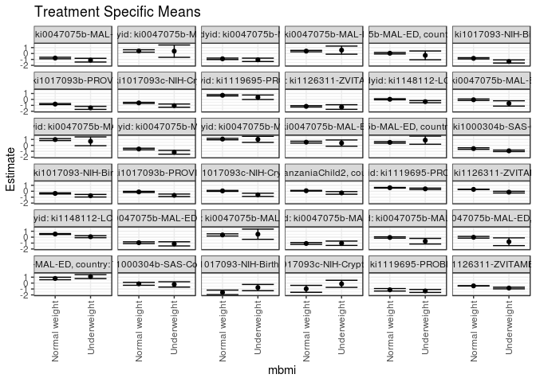

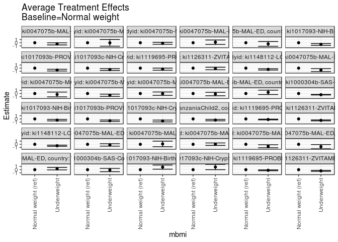

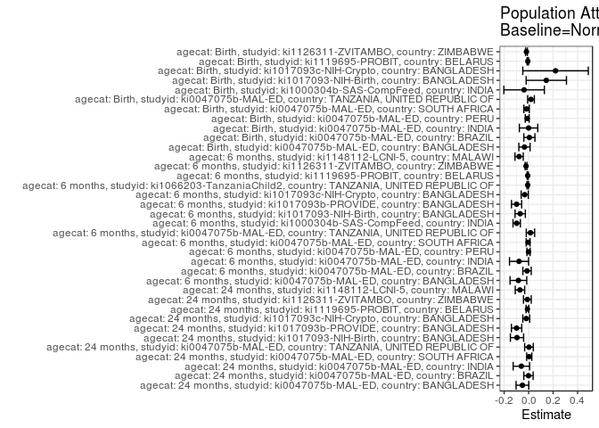

## Results Table

### Parameter: TSM

| agecat | studyid | country | intervention_level | baseline_level | estimate | ci_lower | ci_upper |
| --- | --- | --- | --- | --- | --- | --- | --- |
| Birth | ki0047075b-MAL-ED | BANGLADESH | Normal weight | NA | -0.9385356 | -1.0868587 | -0.7902126 |
| Birth | ki0047075b-MAL-ED | BANGLADESH | Underweight | NA | -1.1340299 | -1.4866735 | -0.7813862 |
| Birth | ki0047075b-MAL-ED | BRAZIL | Normal weight | NA | 0.3770060 | 0.1944840 | 0.5595280 |
| Birth | ki0047075b-MAL-ED | BRAZIL | Underweight | NA | 0.4988889 | -0.3650643 | 1.3628420 |
| Birth | ki0047075b-MAL-ED | INDIA | Normal weight | NA | -1.0694235 | -1.2241988 | -0.9146482 |
| Birth | ki0047075b-MAL-ED | INDIA | Underweight | NA | -1.0310740 | -1.3971770 | -0.6649709 |
| Birth | ki0047075b-MAL-ED | PERU | Normal weight | NA | -0.0544318 | -0.1690482 | 0.0601845 |
| Birth | ki0047075b-MAL-ED | PERU | Underweight | NA | -0.6820000 | -1.1578307 | -0.2061693 |
| Birth | ki0047075b-MAL-ED | SOUTH AFRICA | Normal weight | NA | -0.0178733 | -0.1685692 | 0.1328226 |
| Birth | ki0047075b-MAL-ED | SOUTH AFRICA | Underweight | NA | -0.7740000 | -1.4276053 | -0.1203947 |
| Birth | ki0047075b-MAL-ED | TANZANIA, UNITED REPUBLIC OF | Normal weight | NA | 0.7757798 | 0.5642184 | 0.9873412 |
| Birth | ki0047075b-MAL-ED | TANZANIA, UNITED REPUBLIC OF | Underweight | NA | 1.0942857 | 0.7651658 | 1.4234056 |
| Birth | ki1000304b-SAS-CompFeed | INDIA | Normal weight | NA | -0.1233291 | -0.3703545 | 0.1236964 |
| Birth | ki1000304b-SAS-CompFeed | INDIA | Underweight | NA | -0.2282736 | -0.6784630 | 0.2219158 |
| Birth | ki1017093-NIH-Birth | BANGLADESH | Normal weight | NA | -1.5682609 | -1.9461968 | -1.1903249 |
| Birth | ki1017093-NIH-Birth | BANGLADESH | Underweight | NA | -0.7600000 | -1.2890983 | -0.2309017 |
| Birth | ki1017093c-NIH-Crypto | BANGLADESH | Normal weight | NA | -0.9705882 | -1.5557317 | -0.3854448 |
| Birth | ki1017093c-NIH-Crypto | BANGLADESH | Underweight | NA | -0.1283333 | -0.7259906 | 0.4693239 |
| Birth | ki1119695-PROBIT | BELARUS | Normal weight | NA | -1.1375634 | -1.3478550 | -0.9272719 |
| Birth | ki1119695-PROBIT | BELARUS | Underweight | NA | -1.3284212 | -1.5809508 | -1.0758916 |
| Birth | ki1126311-ZVITAMBO | ZIMBABWE | Normal weight | NA | -0.4719636 | -0.5037106 | -0.4402166 |
| Birth | ki1126311-ZVITAMBO | ZIMBABWE | Underweight | NA | -0.8437958 | -0.9813749 | -0.7062167 |
| 6 months | ki0047075b-MAL-ED | BANGLADESH | Normal weight | NA | -0.0562730 | -0.1860258 | 0.0734798 |
| 6 months | ki0047075b-MAL-ED | BANGLADESH | Underweight | NA | -0.6806080 | -1.1300716 | -0.2311444 |
| 6 months | ki0047075b-MAL-ED | BRAZIL | Normal weight | NA | 0.9775209 | 0.8091090 | 1.1459329 |
| 6 months | ki0047075b-MAL-ED | BRAZIL | Underweight | NA | 0.6764815 | -0.0674862 | 1.4204491 |
| 6 months | ki0047075b-MAL-ED | INDIA | Normal weight | NA | -0.6205209 | -0.7509911 | -0.4900508 |
| 6 months | ki0047075b-MAL-ED | INDIA | Underweight | NA | -1.1712304 | -1.4989125 | -0.8435483 |
| 6 months | ki0047075b-MAL-ED | PERU | Normal weight | NA | 1.0571910 | 0.9326684 | 1.1817136 |
| 6 months | ki0047075b-MAL-ED | PERU | Underweight | NA | 1.0130000 | 0.5008674 | 1.5251326 |
| 6 months | ki0047075b-MAL-ED | SOUTH AFRICA | Normal weight | NA | 0.5333953 | 0.3757046 | 0.6910860 |
| 6 months | ki0047075b-MAL-ED | SOUTH AFRICA | Underweight | NA | 0.3785714 | -0.1478585 | 0.9050014 |
| 6 months | ki0047075b-MAL-ED | TANZANIA, UNITED REPUBLIC OF | Normal weight | NA | 0.5020692 | 0.3685897 | 0.6355486 |
| 6 months | ki0047075b-MAL-ED | TANZANIA, UNITED REPUBLIC OF | Underweight | NA | 0.8746533 | 0.1863927 | 1.5629138 |
| 6 months | ki1000304b-SAS-CompFeed | INDIA | Normal weight | NA | -0.5467905 | -0.6766870 | -0.4168940 |
| 6 months | ki1000304b-SAS-CompFeed | INDIA | Underweight | NA | -0.9297729 | -1.0580355 | -0.8015103 |
| 6 months | ki1017093-NIH-Birth | BANGLADESH | Normal weight | NA | -0.3701381 | -0.4675337 | -0.2727426 |
| 6 months | ki1017093-NIH-Birth | BANGLADESH | Underweight | NA | -0.7586188 | -0.9754176 | -0.5418200 |
| 6 months | ki1017093b-PROVIDE | BANGLADESH | Normal weight | NA | -0.1096204 | -0.2014262 | -0.0178145 |
| 6 months | ki1017093b-PROVIDE | BANGLADESH | Underweight | NA | -0.6880954 | -0.8993355 | -0.4768552 |
| 6 months | ki1017093c-NIH-Crypto | BANGLADESH | Normal weight | NA | 0.0615433 | -0.0203308 | 0.1434174 |
| 6 months | ki1017093c-NIH-Crypto | BANGLADESH | Underweight | NA | -0.6017737 | -0.8697609 | -0.3337864 |
| 6 months | ki1066203-TanzaniaChild2 | TANZANIA, UNITED REPUBLIC OF | Normal weight | NA | 0.0848195 | 0.0302861 | 0.1393529 |
| 6 months | ki1066203-TanzaniaChild2 | TANZANIA, UNITED REPUBLIC OF | Underweight | NA | -0.2839242 | -0.5070418 | -0.0608066 |
| 6 months | ki1119695-PROBIT | BELARUS | Normal weight | NA | 0.5905494 | 0.5328025 | 0.6482963 |
| 6 months | ki1119695-PROBIT | BELARUS | Underweight | NA | 0.4016319 | 0.2765870 | 0.5266769 |
| 6 months | ki1126311-ZVITAMBO | ZIMBABWE | Normal weight | NA | 0.3139892 | 0.2854205 | 0.3425579 |
| 6 months | ki1126311-ZVITAMBO | ZIMBABWE | Underweight | NA | -0.1520822 | -0.2933150 | -0.0108495 |
| 6 months | ki1148112-LCNI-5 | MALAWI | Normal weight | NA | 0.5292328 | 0.4507562 | 0.6077095 |
| 6 months | ki1148112-LCNI-5 | MALAWI | Underweight | NA | 0.0750092 | -0.0927021 | 0.2427205 |
| 24 months | ki0047075b-MAL-ED | BANGLADESH | Normal weight | NA | -0.7702345 | -0.9007873 | -0.6396817 |
| 24 months | ki0047075b-MAL-ED | BANGLADESH | Underweight | NA | -1.1266811 | -1.4406852 | -0.8126770 |
| 24 months | ki0047075b-MAL-ED | BRAZIL | Normal weight | NA | 0.4294444 | 0.2224555 | 0.6364334 |
| 24 months | ki0047075b-MAL-ED | BRAZIL | Underweight | NA | 0.3966667 | -0.6451983 | 1.4385316 |
| 24 months | ki0047075b-MAL-ED | INDIA | Normal weight | NA | -0.8934026 | -1.0176171 | -0.7691881 |
| 24 months | ki0047075b-MAL-ED | INDIA | Underweight | NA | -1.0711306 | -1.3572853 | -0.7849759 |
| 24 months | ki0047075b-MAL-ED | SOUTH AFRICA | Normal weight | NA | 0.4046696 | 0.2835400 | 0.5257992 |
| 24 months | ki0047075b-MAL-ED | SOUTH AFRICA | Underweight | NA | 0.5700000 | -0.1123856 | 1.2523856 |
| 24 months | ki0047075b-MAL-ED | TANZANIA, UNITED REPUBLIC OF | Normal weight | NA | 0.0471425 | -0.0800822 | 0.1743671 |
| 24 months | ki0047075b-MAL-ED | TANZANIA, UNITED REPUBLIC OF | Underweight | NA | -0.3159173 | -1.0577853 | 0.4259506 |
| 24 months | ki1017093-NIH-Birth | BANGLADESH | Normal weight | NA | -0.8166558 | -0.9197061 | -0.7136054 |
| 24 months | ki1017093-NIH-Birth | BANGLADESH | Underweight | NA | -1.3488001 | -1.6100187 | -1.0875815 |
| 24 months | ki1017093b-PROVIDE | BANGLADESH | Normal weight | NA | -0.7880669 | -0.8786534 | -0.6974804 |
| 24 months | ki1017093b-PROVIDE | BANGLADESH | Underweight | NA | -1.4251161 | -1.6831015 | -1.1671307 |
| 24 months | ki1017093c-NIH-Crypto | BANGLADESH | Normal weight | NA | -0.5909852 | -0.6904206 | -0.4915498 |
| 24 months | ki1017093c-NIH-Crypto | BANGLADESH | Underweight | NA | -1.0490269 | -1.3185067 | -0.7795471 |
| 24 months | ki1119695-PROBIT | BELARUS | Normal weight | NA | 0.6967857 | 0.5864206 | 0.8071508 |
| 24 months | ki1119695-PROBIT | BELARUS | Underweight | NA | 0.3628720 | -0.0184776 | 0.7442216 |
| 24 months | ki1126311-ZVITAMBO | ZIMBABWE | Normal weight | NA | -1.1706124 | -1.2848220 | -1.0564028 |
| 24 months | ki1126311-ZVITAMBO | ZIMBABWE | Underweight | NA | -1.2858001 | -1.6725884 | -0.8990117 |
| 24 months | ki1148112-LCNI-5 | MALAWI | Normal weight | NA | 0.0238365 | -0.0659140 | 0.1135870 |
| 24 months | ki1148112-LCNI-5 | MALAWI | Underweight | NA | -0.3790244 | -0.5639245 | -0.1941243 |

### Parameter: E(Y)

| agecat | studyid | country | intervention_level | baseline_level | estimate | ci_lower | ci_upper |
| --- | --- | --- | --- | --- | --- | --- | --- |
| Birth | ki0047075b-MAL-ED | BANGLADESH | NA | NA | -0.9724464 | -1.1091046 | -0.8357881 |
| Birth | ki0047075b-MAL-ED | BRAZIL | NA | NA | 0.3832386 | 0.2044597 | 0.5620175 |
| Birth | ki0047075b-MAL-ED | INDIA | NA | NA | -1.0698974 | -1.2115847 | -0.9282102 |
| Birth | ki0047075b-MAL-ED | PERU | NA | NA | -0.0660967 | -0.1789362 | 0.0467429 |
| Birth | ki0047075b-MAL-ED | SOUTH AFRICA | NA | NA | -0.0346018 | -0.1831486 | 0.1139451 |
| Birth | ki0047075b-MAL-ED | TANZANIA, UNITED REPUBLIC OF | NA | NA | 0.7950000 | 0.5947353 | 0.9952647 |
| Birth | ki1000304b-SAS-CompFeed | INDIA | NA | NA | -0.1601818 | -0.3763991 | 0.0560355 |
| Birth | ki1017093-NIH-Birth | BANGLADESH | NA | NA | -1.4239286 | -1.7688028 | -1.0790544 |
| Birth | ki1017093c-NIH-Crypto | BANGLADESH | NA | NA | -0.7508696 | -1.2358912 | -0.2658480 |
| Birth | ki1119695-PROBIT | BELARUS | NA | NA | -1.1441269 | -1.3547476 | -0.9335062 |
| Birth | ki1126311-ZVITAMBO | ZIMBABWE | NA | NA | -0.4900343 | -0.5209436 | -0.4591251 |
| 6 months | ki0047075b-MAL-ED | BANGLADESH | NA | NA | -0.1397960 | -0.2688682 | -0.0107238 |
| 6 months | ki0047075b-MAL-ED | BRAZIL | NA | NA | 0.9644952 | 0.7999744 | 1.1290160 |
| 6 months | ki0047075b-MAL-ED | INDIA | NA | NA | -0.6987943 | -0.8241325 | -0.5734561 |
| 6 months | ki0047075b-MAL-ED | PERU | NA | NA | 1.0563787 | 0.9342938 | 1.1784635 |
| 6 months | ki0047075b-MAL-ED | SOUTH AFRICA | NA | NA | 0.5290428 | 0.3750394 | 0.6830463 |
| 6 months | ki0047075b-MAL-ED | TANZANIA, UNITED REPUBLIC OF | NA | NA | 0.5170513 | 0.3872178 | 0.6468847 |
| 6 months | ki1000304b-SAS-CompFeed | INDIA | NA | NA | -0.6441020 | -0.7710827 | -0.5171213 |
| 6 months | ki1017093-NIH-Birth | BANGLADESH | NA | NA | -0.4389101 | -0.5279432 | -0.3498771 |
| 6 months | ki1017093b-PROVIDE | BANGLADESH | NA | NA | -0.2079891 | -0.2925599 | -0.1234183 |
| 6 months | ki1017093c-NIH-Crypto | BANGLADESH | NA | NA | 0.0297622 | -0.0491685 | 0.1086930 |
| 6 months | ki1066203-TanzaniaChild2 | TANZANIA, UNITED REPUBLIC OF | NA | NA | 0.0775172 | 0.0241750 | 0.1308595 |
| 6 months | ki1119695-PROBIT | BELARUS | NA | NA | 0.5829956 | 0.5247249 | 0.6412663 |
| 6 months | ki1126311-ZVITAMBO | ZIMBABWE | NA | NA | 0.2928094 | 0.2648167 | 0.3208020 |
| 6 months | ki1148112-LCNI-5 | MALAWI | NA | NA | 0.4515431 | 0.3802415 | 0.5228446 |
| 24 months | ki0047075b-MAL-ED | BANGLADESH | NA | NA | -0.8208255 | -0.9429246 | -0.6987264 |
| 24 months | ki0047075b-MAL-ED | BRAZIL | NA | NA | 0.4282738 | 0.2252365 | 0.6313111 |
| 24 months | ki0047075b-MAL-ED | INDIA | NA | NA | -0.9525664 | -1.0684455 | -0.8366872 |
| 24 months | ki0047075b-MAL-ED | SOUTH AFRICA | NA | NA | 0.4096154 | 0.2902946 | 0.5289362 |
| 24 months | ki0047075b-MAL-ED | TANZANIA, UNITED REPUBLIC OF | NA | NA | 0.0500935 | -0.0748234 | 0.1750103 |
| 24 months | ki1017093-NIH-Birth | BANGLADESH | NA | NA | -0.9115790 | -1.0095022 | -0.8136559 |
| 24 months | ki1017093b-PROVIDE | BANGLADESH | NA | NA | -0.8864991 | -0.9695215 | -0.8034768 |
| 24 months | ki1017093c-NIH-Crypto | BANGLADESH | NA | NA | -0.6103502 | -0.7050157 | -0.5156847 |
| 24 months | ki1119695-PROBIT | BELARUS | NA | NA | 0.6869754 | 0.5725638 | 0.8013869 |
| 24 months | ki1126311-ZVITAMBO | ZIMBABWE | NA | NA | -1.1810028 | -1.2914599 | -1.0705456 |
| 24 months | ki1148112-LCNI-5 | MALAWI | NA | NA | -0.0469519 | -0.1290932 | 0.0351895 |

### Parameter: ATE

| agecat | studyid | country | intervention_level | baseline_level | estimate | ci_lower | ci_upper |
| --- | --- | --- | --- | --- | --- | --- | --- |
| Birth | ki0047075b-MAL-ED | BANGLADESH | Normal weight | Normal weight | 0.0000000 | 0.0000000 | 0.0000000 |
| Birth | ki0047075b-MAL-ED | BANGLADESH | Underweight | Normal weight | -0.1954942 | -0.5801103 | 0.1891219 |
| Birth | ki0047075b-MAL-ED | BRAZIL | Normal weight | Normal weight | 0.0000000 | 0.0000000 | 0.0000000 |
| Birth | ki0047075b-MAL-ED | BRAZIL | Underweight | Normal weight | 0.1218829 | -0.7611399 | 1.0049057 |
| Birth | ki0047075b-MAL-ED | INDIA | Normal weight | Normal weight | 0.0000000 | 0.0000000 | 0.0000000 |
| Birth | ki0047075b-MAL-ED | INDIA | Underweight | Normal weight | 0.0383495 | -0.3601566 | 0.4368556 |
| Birth | ki0047075b-MAL-ED | PERU | Normal weight | Normal weight | 0.0000000 | 0.0000000 | 0.0000000 |
| Birth | ki0047075b-MAL-ED | PERU | Underweight | Normal weight | -0.6275682 | -1.1170084 | -0.1381280 |
| Birth | ki0047075b-MAL-ED | SOUTH AFRICA | Normal weight | Normal weight | 0.0000000 | 0.0000000 | 0.0000000 |
| Birth | ki0047075b-MAL-ED | SOUTH AFRICA | Underweight | Normal weight | -0.7561267 | -1.4268793 | -0.0853741 |
| Birth | ki0047075b-MAL-ED | TANZANIA, UNITED REPUBLIC OF | Normal weight | Normal weight | 0.0000000 | 0.0000000 | 0.0000000 |
| Birth | ki0047075b-MAL-ED | TANZANIA, UNITED REPUBLIC OF | Underweight | Normal weight | 0.3185059 | -0.0727461 | 0.7097579 |
| Birth | ki1000304b-SAS-CompFeed | INDIA | Normal weight | Normal weight | 0.0000000 | 0.0000000 | 0.0000000 |
| Birth | ki1000304b-SAS-CompFeed | INDIA | Underweight | Normal weight | -0.1049445 | -0.6239766 | 0.4140876 |
| Birth | ki1017093-NIH-Birth | BANGLADESH | Normal weight | Normal weight | 0.0000000 | 0.0000000 | 0.0000000 |
| Birth | ki1017093-NIH-Birth | BANGLADESH | Underweight | Normal weight | 0.8082609 | 0.1580450 | 1.4584767 |
| Birth | ki1017093c-NIH-Crypto | BANGLADESH | Normal weight | Normal weight | 0.0000000 | 0.0000000 | 0.0000000 |
| Birth | ki1017093c-NIH-Crypto | BANGLADESH | Underweight | Normal weight | 0.8422549 | 0.0058417 | 1.6786681 |
| Birth | ki1119695-PROBIT | BELARUS | Normal weight | Normal weight | 0.0000000 | 0.0000000 | 0.0000000 |
| Birth | ki1119695-PROBIT | BELARUS | Underweight | Normal weight | -0.1908578 | -0.3344150 | -0.0473006 |
| Birth | ki1126311-ZVITAMBO | ZIMBABWE | Normal weight | Normal weight | 0.0000000 | 0.0000000 | 0.0000000 |
| Birth | ki1126311-ZVITAMBO | ZIMBABWE | Underweight | Normal weight | -0.3718322 | -0.5130527 | -0.2306117 |
| 6 months | ki0047075b-MAL-ED | BANGLADESH | Normal weight | Normal weight | 0.0000000 | 0.0000000 | 0.0000000 |
| 6 months | ki0047075b-MAL-ED | BANGLADESH | Underweight | Normal weight | -0.6243350 | -1.0921643 | -0.1565056 |
| 6 months | ki0047075b-MAL-ED | BRAZIL | Normal weight | Normal weight | 0.0000000 | 0.0000000 | 0.0000000 |
| 6 months | ki0047075b-MAL-ED | BRAZIL | Underweight | Normal weight | -0.3010395 | -1.0638307 | 0.4617517 |
| 6 months | ki0047075b-MAL-ED | INDIA | Normal weight | Normal weight | 0.0000000 | 0.0000000 | 0.0000000 |
| 6 months | ki0047075b-MAL-ED | INDIA | Underweight | Normal weight | -0.5507094 | -0.9055798 | -0.1958391 |
| 6 months | ki0047075b-MAL-ED | PERU | Normal weight | Normal weight | 0.0000000 | 0.0000000 | 0.0000000 |
| 6 months | ki0047075b-MAL-ED | PERU | Underweight | Normal weight | -0.0441910 | -0.5712448 | 0.4828628 |
| 6 months | ki0047075b-MAL-ED | SOUTH AFRICA | Normal weight | Normal weight | 0.0000000 | 0.0000000 | 0.0000000 |
| 6 months | ki0047075b-MAL-ED | SOUTH AFRICA | Underweight | Normal weight | -0.1548239 | -0.7043645 | 0.3947167 |
| 6 months | ki0047075b-MAL-ED | TANZANIA, UNITED REPUBLIC OF | Normal weight | Normal weight | 0.0000000 | 0.0000000 | 0.0000000 |
| 6 months | ki0047075b-MAL-ED | TANZANIA, UNITED REPUBLIC OF | Underweight | Normal weight | 0.3725841 | -0.3318301 | 1.0769983 |
| 6 months | ki1000304b-SAS-CompFeed | INDIA | Normal weight | Normal weight | 0.0000000 | 0.0000000 | 0.0000000 |
| 6 months | ki1000304b-SAS-CompFeed | INDIA | Underweight | Normal weight | -0.3829824 | -0.4679009 | -0.2980639 |
| 6 months | ki1017093-NIH-Birth | BANGLADESH | Normal weight | Normal weight | 0.0000000 | 0.0000000 | 0.0000000 |
| 6 months | ki1017093-NIH-Birth | BANGLADESH | Underweight | Normal weight | -0.3884807 | -0.6265977 | -0.1503637 |
| 6 months | ki1017093b-PROVIDE | BANGLADESH | Normal weight | Normal weight | 0.0000000 | 0.0000000 | 0.0000000 |
| 6 months | ki1017093b-PROVIDE | BANGLADESH | Underweight | Normal weight | -0.5784750 | -0.8087292 | -0.3482208 |
| 6 months | ki1017093c-NIH-Crypto | BANGLADESH | Normal weight | Normal weight | 0.0000000 | 0.0000000 | 0.0000000 |
| 6 months | ki1017093c-NIH-Crypto | BANGLADESH | Underweight | Normal weight | -0.6633169 | -0.9440363 | -0.3825976 |
| 6 months | ki1066203-TanzaniaChild2 | TANZANIA, UNITED REPUBLIC OF | Normal weight | Normal weight | 0.0000000 | 0.0000000 | 0.0000000 |
| 6 months | ki1066203-TanzaniaChild2 | TANZANIA, UNITED REPUBLIC OF | Underweight | Normal weight | -0.3687437 | -0.5983159 | -0.1391715 |
| 6 months | ki1119695-PROBIT | BELARUS | Normal weight | Normal weight | 0.0000000 | 0.0000000 | 0.0000000 |
| 6 months | ki1119695-PROBIT | BELARUS | Underweight | Normal weight | -0.1889175 | -0.2999868 | -0.0778482 |
| 6 months | ki1126311-ZVITAMBO | ZIMBABWE | Normal weight | Normal weight | 0.0000000 | 0.0000000 | 0.0000000 |
| 6 months | ki1126311-ZVITAMBO | ZIMBABWE | Underweight | Normal weight | -0.4660714 | -0.6101327 | -0.3220100 |
| 6 months | ki1148112-LCNI-5 | MALAWI | Normal weight | Normal weight | 0.0000000 | 0.0000000 | 0.0000000 |
| 6 months | ki1148112-LCNI-5 | MALAWI | Underweight | Normal weight | -0.4542236 | -0.6398479 | -0.2685994 |
| 24 months | ki0047075b-MAL-ED | BANGLADESH | Normal weight | Normal weight | 0.0000000 | 0.0000000 | 0.0000000 |
| 24 months | ki0047075b-MAL-ED | BANGLADESH | Underweight | Normal weight | -0.3564466 | -0.6951311 | -0.0177620 |
| 24 months | ki0047075b-MAL-ED | BRAZIL | Normal weight | Normal weight | 0.0000000 | 0.0000000 | 0.0000000 |
| 24 months | ki0047075b-MAL-ED | BRAZIL | Underweight | Normal weight | -0.0327778 | -1.0950051 | 1.0294496 |
| 24 months | ki0047075b-MAL-ED | INDIA | Normal weight | Normal weight | 0.0000000 | 0.0000000 | 0.0000000 |
| 24 months | ki0047075b-MAL-ED | INDIA | Underweight | Normal weight | -0.1777280 | -0.4906587 | 0.1352028 |
| 24 months | ki0047075b-MAL-ED | SOUTH AFRICA | Normal weight | Normal weight | 0.0000000 | 0.0000000 | 0.0000000 |
| 24 months | ki0047075b-MAL-ED | SOUTH AFRICA | Underweight | Normal weight | 0.1653304 | -0.5277226 | 0.8583834 |
| 24 months | ki0047075b-MAL-ED | TANZANIA, UNITED REPUBLIC OF | Normal weight | Normal weight | 0.0000000 | 0.0000000 | 0.0000000 |
| 24 months | ki0047075b-MAL-ED | TANZANIA, UNITED REPUBLIC OF | Underweight | Normal weight | -0.3630598 | -1.1160743 | 0.3899547 |
| 24 months | ki1017093-NIH-Birth | BANGLADESH | Normal weight | Normal weight | 0.0000000 | 0.0000000 | 0.0000000 |
| 24 months | ki1017093-NIH-Birth | BANGLADESH | Underweight | Normal weight | -0.5321443 | -0.8127806 | -0.2515079 |
| 24 months | ki1017093b-PROVIDE | BANGLADESH | Normal weight | Normal weight | 0.0000000 | 0.0000000 | 0.0000000 |
| 24 months | ki1017093b-PROVIDE | BANGLADESH | Underweight | Normal weight | -0.6370492 | -0.9098662 | -0.3642322 |
| 24 months | ki1017093c-NIH-Crypto | BANGLADESH | Normal weight | Normal weight | 0.0000000 | 0.0000000 | 0.0000000 |
| 24 months | ki1017093c-NIH-Crypto | BANGLADESH | Underweight | Normal weight | -0.4580417 | -0.7460482 | -0.1700352 |
| 24 months | ki1119695-PROBIT | BELARUS | Normal weight | Normal weight | 0.0000000 | 0.0000000 | 0.0000000 |
| 24 months | ki1119695-PROBIT | BELARUS | Underweight | Normal weight | -0.3339137 | -0.6692249 | 0.0013975 |
| 24 months | ki1126311-ZVITAMBO | ZIMBABWE | Normal weight | Normal weight | 0.0000000 | 0.0000000 | 0.0000000 |
| 24 months | ki1126311-ZVITAMBO | ZIMBABWE | Underweight | Normal weight | -0.1151876 | -0.5180546 | 0.2876793 |
| 24 months | ki1148112-LCNI-5 | MALAWI | Normal weight | Normal weight | 0.0000000 | 0.0000000 | 0.0000000 |
| 24 months | ki1148112-LCNI-5 | MALAWI | Underweight | Normal weight | -0.4028608 | -0.6088315 | -0.1968902 |

### Parameter: PAR

| agecat | studyid | country | intervention_level | baseline_level | estimate | ci_lower | ci_upper |
| --- | --- | --- | --- | --- | --- | --- | --- |
| Birth | ki0047075b-MAL-ED | BANGLADESH | Normal weight | NA | -0.0339107 | -0.0798808 | 0.0120594 |
| Birth | ki0047075b-MAL-ED | BRAZIL | Normal weight | NA | 0.0062326 | -0.0390968 | 0.0515621 |
| Birth | ki0047075b-MAL-ED | INDIA | Normal weight | NA | -0.0004739 | -0.0756578 | 0.0747099 |
| Birth | ki0047075b-MAL-ED | PERU | Normal weight | NA | -0.0116648 | -0.0275614 | 0.0042317 |
| Birth | ki0047075b-MAL-ED | SOUTH AFRICA | Normal weight | NA | -0.0167285 | -0.0389179 | 0.0054610 |
| Birth | ki0047075b-MAL-ED | TANZANIA, UNITED REPUBLIC OF | Normal weight | NA | 0.0192202 | -0.0081584 | 0.0465987 |
| Birth | ki1000304b-SAS-CompFeed | INDIA | Normal weight | NA | -0.0368528 | -0.2022097 | 0.1285042 |
| Birth | ki1017093-NIH-Birth | BANGLADESH | Normal weight | NA | 0.1443323 | -0.0203351 | 0.3089996 |
| Birth | ki1017093c-NIH-Crypto | BANGLADESH | Normal weight | NA | 0.2197187 | -0.0476628 | 0.4871001 |
| Birth | ki1119695-PROBIT | BELARUS | Normal weight | NA | -0.0065635 | -0.0121307 | -0.0009963 |
| Birth | ki1126311-ZVITAMBO | ZIMBABWE | Normal weight | NA | -0.0180707 | -0.0252036 | -0.0109379 |
| 6 months | ki0047075b-MAL-ED | BANGLADESH | Normal weight | NA | -0.0835230 | -0.1517323 | -0.0153137 |
| 6 months | ki0047075b-MAL-ED | BRAZIL | Normal weight | NA | -0.0130257 | -0.0470695 | 0.0210180 |
| 6 months | ki0047075b-MAL-ED | INDIA | Normal weight | NA | -0.0782734 | -0.1563038 | -0.0002430 |
| 6 months | ki0047075b-MAL-ED | PERU | Normal weight | NA | -0.0008123 | -0.0140076 | 0.0123830 |
| 6 months | ki0047075b-MAL-ED | SOUTH AFRICA | Normal weight | NA | -0.0043525 | -0.0201263 | 0.0114214 |
| 6 months | ki0047075b-MAL-ED | TANZANIA, UNITED REPUBLIC OF | Normal weight | NA | 0.0149821 | -0.0191097 | 0.0490739 |
| 6 months | ki1000304b-SAS-CompFeed | INDIA | Normal weight | NA | -0.0973115 | -0.1274014 | -0.0672217 |
| 6 months | ki1017093-NIH-Birth | BANGLADESH | Normal weight | NA | -0.0687720 | -0.1108248 | -0.0267192 |
| 6 months | ki1017093b-PROVIDE | BANGLADESH | Normal weight | NA | -0.0983687 | -0.1400101 | -0.0567274 |
| 6 months | ki1017093c-NIH-Crypto | BANGLADESH | Normal weight | NA | -0.0317810 | -0.0608092 | -0.0027529 |
| 6 months | ki1066203-TanzaniaChild2 | TANZANIA, UNITED REPUBLIC OF | Normal weight | NA | -0.0073023 | -0.0136273 | -0.0009772 |
| 6 months | ki1119695-PROBIT | BELARUS | Normal weight | NA | -0.0075538 | -0.0118933 | -0.0032143 |
| 6 months | ki1126311-ZVITAMBO | ZIMBABWE | Normal weight | NA | -0.0211798 | -0.0284380 | -0.0139216 |
| 6 months | ki1148112-LCNI-5 | MALAWI | Normal weight | NA | -0.0776898 | -0.1114865 | -0.0438930 |
| 24 months | ki0047075b-MAL-ED | BANGLADESH | Normal weight | NA | -0.0505910 | -0.1025858 | 0.0014039 |
| 24 months | ki0047075b-MAL-ED | BRAZIL | Normal weight | NA | -0.0011706 | -0.0391185 | 0.0367773 |
| 24 months | ki0047075b-MAL-ED | INDIA | Normal weight | NA | -0.0591638 | -0.1262692 | 0.0079416 |
| 24 months | ki0047075b-MAL-ED | SOUTH AFRICA | Normal weight | NA | 0.0049458 | -0.0160996 | 0.0259912 |
| 24 months | ki0047075b-MAL-ED | TANZANIA, UNITED REPUBLIC OF | Normal weight | NA | 0.0029510 | -0.0322384 | 0.0381403 |
| 24 months | ki1017093-NIH-Birth | BANGLADESH | Normal weight | NA | -0.0949233 | -0.1489434 | -0.0409031 |
| 24 months | ki1017093b-PROVIDE | BANGLADESH | Normal weight | NA | -0.0984322 | -0.1406453 | -0.0562191 |
| 24 months | ki1017093c-NIH-Crypto | BANGLADESH | Normal weight | NA | -0.0193650 | -0.0475288 | 0.0087988 |
| 24 months | ki1119695-PROBIT | BELARUS | Normal weight | NA | -0.0098103 | -0.0208742 | 0.0012536 |
| 24 months | ki1126311-ZVITAMBO | ZIMBABWE | Normal weight | NA | -0.0103904 | -0.0419235 | 0.0211428 |
| 24 months | ki1148112-LCNI-5 | MALAWI | Normal weight | NA | -0.0707883 | -0.1094051 | -0.0321716 |